# Precipitation forecasting

```python
from IPython.display import HTML

HTML('''<script>
code_show=true;
function code_toggle() {
 if (code_show){
 $('div.input').hide();
 } else {
 $('div.input').show();
 }
 code_show = !code_show
}
$( document ).ready(code_toggle);
</script>
<form action="javascript:code_toggle()"><input type="submit" value="Click here to toggle on/off the raw code."></form>''')
```

```python
def replacer(val):
    if val<15:
        val=0
    return val
```

```python
def check_AIC_BIC(train):
    p=d=q=range(0,2)
    pdq = list(itertools.product(p, d, q))
    seasonal_pdq = [(x[0], x[1], x[2], 12) for x in pdq]
    warnings.filterwarnings("ignore")
    model_aic_list=[]
    for param in pdq:
        for param_seasonal in seasonal_pdq:
                mod = sm.tsa.statespace.SARIMAX(train,
                                                order=param,
                                                seasonal_order=param_seasonal,
                                                enforce_stationarity=False,
                                                enforce_invertibility=False)

                results = mod.fit()
                model_aic_list.append([param,param_seasonal,results.aic,results.bic])
    return model_aic_list
```

```python
def test_stationarity(timeseries):
    rolmean = timeseries.rolling(12).mean()
    rolstd = timeseries.rolling(12).std()
    fig = plt.figure(figsize=(12, 8))
    orig = plt.plot(timeseries, color='blue',label='Original')
    mean = plt.plot(rolmean, color='red', label='Rolling Mean')
    std = plt.plot(rolstd, color='black', label = 'Rolling Std')
    plt.legend(loc='best')
    plt.title('Rolling Mean & Standard Deviation')
    plt.show()
    print('Results of Dickey-Fuller Test:')
    dftest = adfuller(timeseries, autolag='AIC')
    dfoutput = pd.Series(dftest[0:4], index=['Test Statistic','p-value','#Lags Used','Number of Observations Used'])
    for key,value in dftest[4].items():
        dfoutput['Critical Value (%s)'%key] = value
    print(dfoutput)
    return dfoutput[0]<dfoutput[4]
```

```python
def FTS_replacer(val):
    val=val-15
    if val<15:
        val=0
    return val
```

```python
def SARIMAX_model(train,test,order,sorder):
    model=SARIMAX(train,order=order,seasonal_order=sorder,enforce_stationarity=False,enforce_invertibility=False)
    fitted=model.fit(disp=False)
    forecasts=fitted.forecast(60)
    RMSE=np.sqrt(mean_squared_error(forecasts,test))
    print('RMSE: {}'.format(RMSE))
    plt.figure(figsize=(12, 6))
    plt.title('Rainfall Forecast', fontsize=30)
    plt.plot((forecasts), label='Forecast')
    plt.plot((test), label='Test')
    plt.legend(fontsize=25)
    return forecasts.resample('Y').sum()
```

```python
import math
import pandas as pd
import itertools
import numpy as np
import seaborn as sns
import matplotlib.pyplot as plt
import warnings
import statsmodels.api as sm
from statsmodels.tsa.seasonal import seasonal_decompose
from statsmodels.tsa.stattools import adfuller
from scipy import stats
from scipy.special import boxcox1p,inv_boxcox
from scipy.stats import boxcox
from sklearn.metrics import mean_squared_error,mean_absolute_error
from statsmodels.graphics.tsaplots import plot_acf, plot_pacf
from statsmodels.tsa.statespace.sarimax import SARIMAX
from pyFTS.data import Enrollments
from pyFTS.common import Transformations
from pyFTS.partitioners import Grid,CMeans,Entropy,FCM
from pyFTS.common import Membership as mf
from pyFTS.models import chen
from pyFTS.models.ensemble import ensemble
from pyFTS.models.pwfts import ProbabilisticWeightedFTS
from pyFTS.models.hofts import HighOrderFTS,WeightedHighOrderFTS
from pyFTS.models.nonstationary import partitioners as nspart
from pyFTS.models.nonstationary import nsfts
from pyFTS.models.incremental import TimeVariant
from pyFTS.models.incremental import IncrementalEnsemble,TimeVariant
from stldecompose import decompose, forecast
% matplotlib inline
```

## Objectives:

### Predicting rainfall for the state of Telangana for the years 2018-2024.

## Methods Used:

### Sarimax and Fuzzytime series.

```python
Telangana=pd.read_excel(r'C:\Users\MUKU\Desktop\Python\Data sets\FHD Data sets\Rain Data\Telangana.xlsx')
```

```python
Tdf=Telangana.set_index(Telangana['Date']).drop(['Date'],axis=1)
```

## We need to check for stationarity of our data. To do so we need to do a Dickey-Fuller Test and see if our data meets certain criterias.

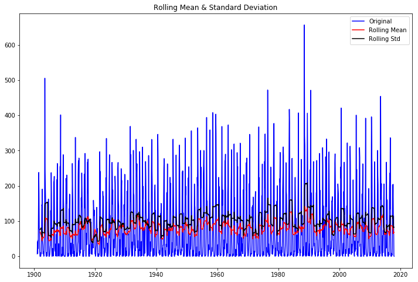

```
Results of Dickey-Fuller Test:
Test Statistic                -5.887226e+00
p-value                        2.981854e-07
#Lags Used                     2.400000e+01
Number of Observations Used    1.379000e+03
Critical Value (1%)           -3.435101e+00
Critical Value (5%)           -2.863638e+00
Critical Value (10%)          -2.567887e+00
dtype: float64
```

```
True
```

```python
test_stationarity(Tdf['Rainfall'])
```

### Here we can see that our data meets the test criteria. This means that we will not need to transform our data as it is already stationary.

#### What to do if the data was not stationary?

- We would have to try out different transformations.
- Repeat the Dickey-Fuller Test and re check the criterias until they are satisfied.

**Common Transformations:**

1. First Difference
2. Seasonal Difference
3. BoxCox Power Transformation.
4. Log,Squareroot etc.

## Visualising the rain data trend and distribution

### Observed line

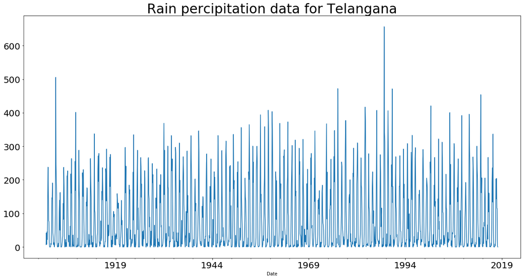

```python
Telangana['Rainfall'].plot(figsize=(20, 10), fontsize=20)
plt.title('Rain percipitation data for Telangana', fontsize=30)
```

### Rain Percipitation Distribution

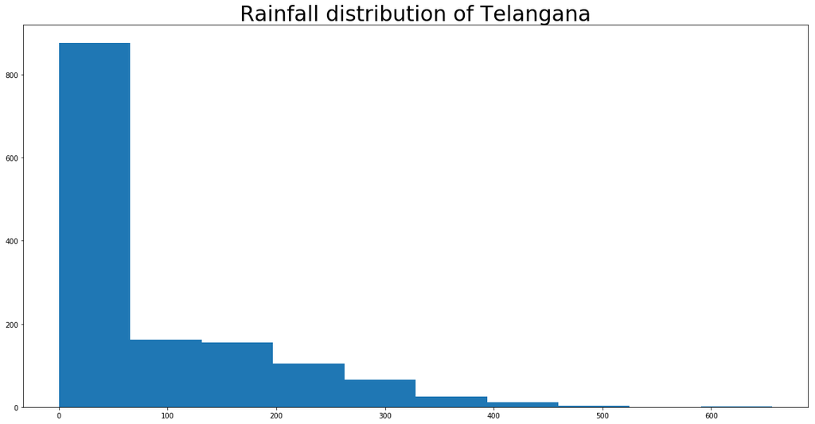

```python
plt.figure(figsize=(20,10))
histogram=plt.hist(Tdf['Rainfall'])
title=plt.title('Rainfall distribution of Telangana',fontsize=30)
```

## We Decompose our data into 3 categories to further understand what we observe from the data.

### Trend:

- This basically gives us an idea of the change in variance and mean of our trend.
- It also tells us if our data is stationary or not.

### Seasonality:

- It tells us about the cyclical trend of our data. Weather our data is Time variant or not.

### Random Noise:

- This is gives us an idea of the randomness in our data.

## Seasonal Decomposition of the our time series data.

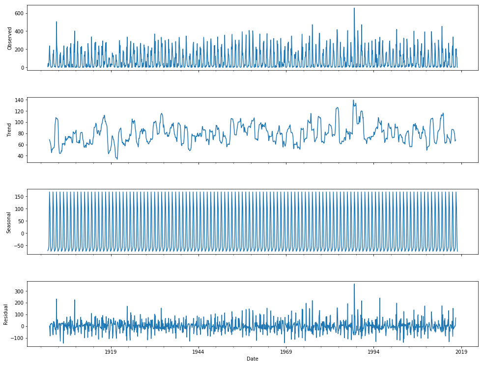

```python
decomposition = seasonal_decompose(Tdf.Rainfall, freq=12)
fig = plt.figure()
fig = decomposition.plot()
fig.set_size_inches(15, 12)
```

## Auto Correlation and Partial Corelation plots.

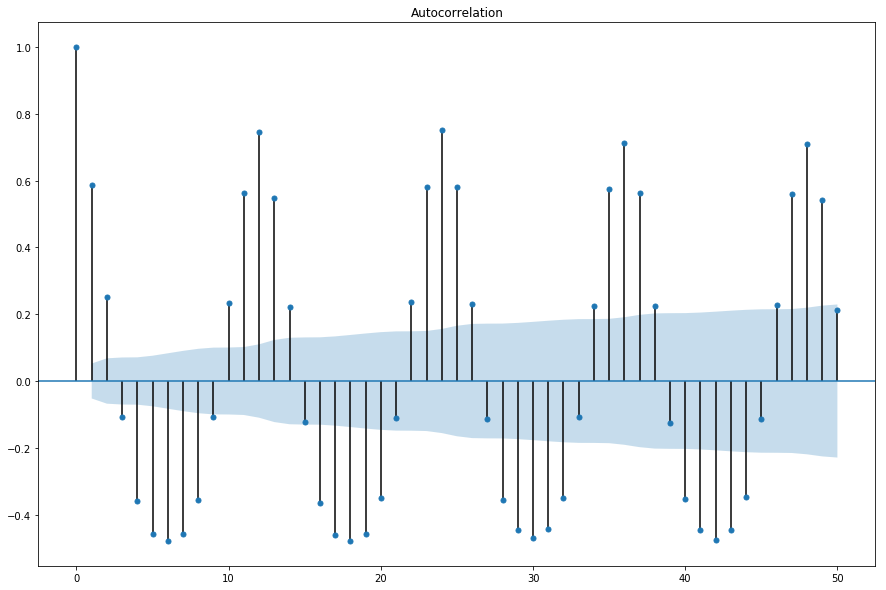

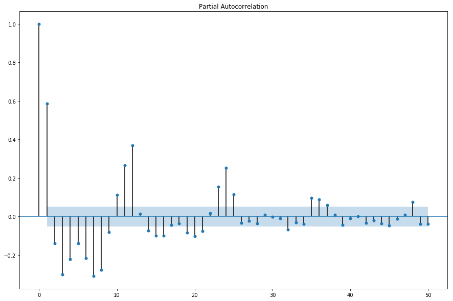

```python
f_acf = plot_acf(Tdf['Rainfall'].dropna(), lags=50)
f_pacf = plot_pacf(Tdf['Rainfall'].dropna(), lags=50, method='ols')
f_acf.set_figheight(10)
f_acf.set_figwidth(15)
f_pacf.set_figheight(10)
f_pacf.set_figwidth(15)
```

## A little about AC and PAC

- These Correlation plots tell us about the correlation between the latest point and the points that show up in the time period before.
- Every relation has two components magnitude and direction.
- The AC tells us about the direct and indirect correlation between two points in time.
- The PAC tells us about only the direct correlation between two points in time.
- All the values outside of the blue area are points that are statistically significant.
- We can use these plots to further tune our parameters

# SARIMAX

#### Here we have used the SARIMAX model which is a seasonal variation of ARIMA(Auto Regressive integrated moving averages).

#### This method takes into account the seasonality of our data.

#### First we used a basic grid search and then by reading the AC and PAC we come to the final conclusion for our parameters for the SARIMAX model.

#### Next we make the prediction for the years 2018-2024 using data from 1988 and another from 1901.

## Grid Searching parameters for our SARIMAX Model

- #### Trying out different combinations of 0 and 1 in place of 6 different parameters. The parameters take values higher than 1 as well but it tends to get computationally expensive.
- #### We shall be using other methods that involve reading the AC and PAC chart to come up with values that are higher than 1 for our parameters.
- #### For every model we calculate the AIC and pick the model with the lowest AIC.
- #### This model with the lowest AIC will be our base model.

```python
models=pd.DataFrame(check_AIC_BIC(train.dropna()))
modeled=models[models[2]==models[2].min()]
modeled.columns=['Order','Seasonal Order','AIC','BIC']
modeled
```

|  | Order | Seasonal Order | AIC | BIC |
| --- | --- | --- | --- | --- |
| 43 | (1, 0, 1) | (0, 1, 1, 12) | 14146.899838 | 14167.635321 |

### Summary of our model

```python
model = SARIMAX(train, order=(1,0,1), seasonal_order=(0,1,1,12),enforce_stationarity=False,enforce_invertibility=False)
model_fit = model.fit(disp=False)
model_fit.summary()
```

Statespace Model Results

| Dep. Variable: | Rainfall | No. Observations: | 1344 |
| --- | --- | --- | --- |
| Model: | SARIMAX(1, 0, 1)x(0, 1, 1, 12) | Log Likelihood | -7069.450 |
| Date: | Tue, 21 May 2019 | AIC | 14146.900 |
| Time: | 10:56:36 | BIC | 14167.635 |
| Sample: | 01-01-1901 | HQIC | 14154.675 |
|  | - 12-01-2012 |  |  |
| Covariance Type: | opg |  |  |

|  | coef | std err | z | P>\|z\| | [0.025 | 0.975] |
| --- | --- | --- | --- | --- | --- | --- |
| ar.L1 | 0.5896 | 0.243 | 2.422 | 0.015 | 0.112 | 1.067 |
| ma.L1 | -0.5197 | 0.252 | -2.062 | 0.039 | -1.014 | -0.026 |
| ma.S.L12 | -1.0465 | 0.007 | -160.374 | 0.000 | -1.059 | -1.034 |
| sigma2 | 2398.0522 | 58.222 | 41.188 | 0.000 | 2283.938 | 2512.166 |

| Ljung-Box (Q): | 56.38 | Jarque-Bera (JB): | 2363.58 |
| --- | --- | --- | --- |
| Prob(Q): | 0.04 | Prob(JB): | 0.00 |
| Heteroskedasticity (H): | 1.39 | Skew: | 1.20 |
| Prob(H) (two-sided): | 0.00 | Kurtosis: | 9.11 |

Warnings:  
[1] Covariance matrix calculated using the outer product of gradients (complex-step).

### Looking at the summary the parameters that are chosen show a p value less than 0.05 this means that they are statistically significant parameters.

## Reading the AC and PAC Charts

```python
model_b=SARIMAX(Tdf['Rainfall'],order=(3,1,0),seasonal_order=(3,1,0,12),enforce_stationarity=False,enforce_invertibility=False)
fitted_b=model_b.fit(disp=False)
fitted_b.summary()
```

Statespace Model Results

| Dep. Variable: | Rainfall | No. Observations: | 1404 |
| --- | --- | --- | --- |
| Model: | SARIMAX(3, 1, 0)x(3, 1, 0, 12) | Log Likelihood | -7520.873 |
| Date: | Wed, 22 May 2019 | AIC | 15055.745 |
| Time: | 12:44:44 | BIC | 15092.210 |
| Sample: | 01-01-1901 | HQIC | 15069.400 |
|  | - 12-01-2017 |  |  |
| Covariance Type: | opg |  |  |

|  | coef | std err | z | P>\|z\| | [0.025 | 0.975] |
| --- | --- | --- | --- | --- | --- | --- |
| ar.L1 | -0.7418 | 0.020 | -36.549 | 0.000 | -0.782 | -0.702 |
| ar.L2 | -0.4508 | 0.028 | -15.845 | 0.000 | -0.507 | -0.395 |
| ar.L3 | -0.2147 | 0.026 | -8.241 | 0.000 | -0.266 | -0.164 |
| ar.S.L12 | -0.6830 | 0.021 | -32.616 | 0.000 | -0.724 | -0.642 |
| ar.S.L24 | -0.3980 | 0.021 | -18.888 | 0.000 | -0.439 | -0.357 |
| ar.S.L36 | -0.2229 | 0.019 | -11.799 | 0.000 | -0.260 | -0.186 |
| sigma2 | 3974.6029 | 93.932 | 42.314 | 0.000 | 3790.500 | 4158.705 |

| Ljung-Box (Q): | 179.27 | Jarque-Bera (JB): | 747.84 |
| --- | --- | --- | --- |
| Prob(Q): | 0.00 | Prob(JB): | 0.00 |
| Heteroskedasticity (H): | 1.56 | Skew: | 0.34 |
| Prob(H) (two-sided): | 0.00 | Kurtosis: | 6.58 |

Warnings:  
[1] Covariance matrix calculated using the outer product of gradients (complex-step).

### Similary we have included more parameters and all the p values of the parameters are lower than 0.05. This is a good fit.

#### Scenario 2:

- Using the entirety of the data set along with parameters obtained from reading the AC and PAC.

#### Scenario 4:

- Using data from the year 1988 to 2012 and parameters obtained from reading the AC and PAC.

## Splitting the data into train and test and predicting.

### Scenario 1:

```python
trains1 = Tdf['Rainfall'].iloc[:-60]
tests1 =Tdf['Rainfall'].iloc[-60:]
orders1=(1,0,1)
sorders1=(1,1,1,12)
```

```
RMSE: 59.431326889611356
```

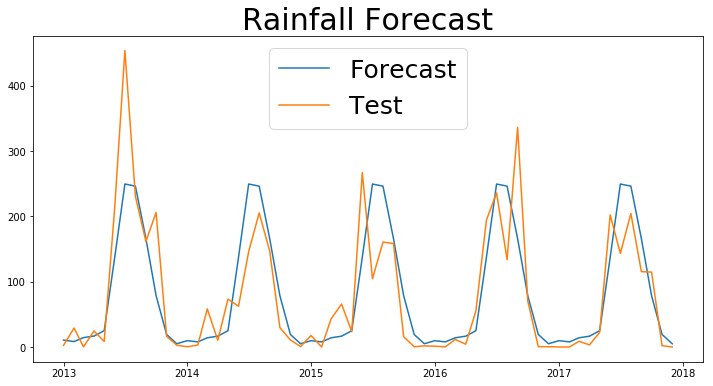

```python
SARIMAX_model(trains1,tests1,orders1,sorders1)
```

[output not shown]

### Scenario 2:

```python
trains2 = Tdf['Rainfall'].iloc[:-60]
tests2 =Tdf['Rainfall'].iloc[-60:]
orders2=(3,1,0)
sorders2=(3,1,0,12)
```

```
RMSE: 72.08504302412516
```

```
2013-12-31    1079.426104
2014-12-31    1226.932947
2015-12-31    1213.520053
2016-12-31    1322.096656
2017-12-31    1393.236810
Freq: A-DEC, dtype: float64
```

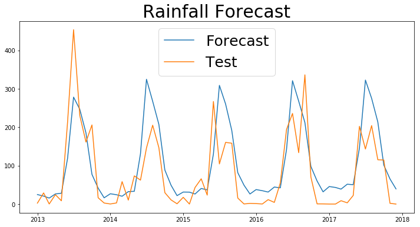

```python
SARIMAX_model(trains2,tests2,orders2,sorders2)
```

### Scenario 3:

```python
trains3 = Tdf['Rainfall'].loc['1988-01-01':'2012-12-01']
tests3 =Tdf['Rainfall'].iloc[-60:]
orders3=(1,0,1)
sorders3=(1,1,1,12)
```

```
RMSE: 60.60401797520287
```

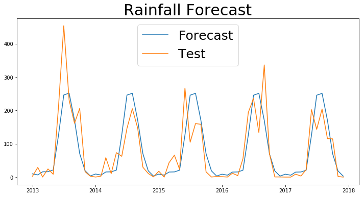

```python
SARIMAX_model(trains3,tests3,orders3,sorders3)
```

[output not shown]

### Scenario 4:

```python
trains4 = Tdf['Rainfall'].loc['1988-01-01':'2012-12-01']
tests4 =Tdf['Rainfall'].iloc[-60:]
orders4=(3,1,0)
sorders4=(3,1,0,12)
```

```
RMSE: 69.3740829985246
```

```
2013-12-31     976.157103
2014-12-31    1141.100677
2015-12-31    1133.081691
2016-12-31    1238.696102
2017-12-31    1274.569044
Freq: A-DEC, dtype: float64
```

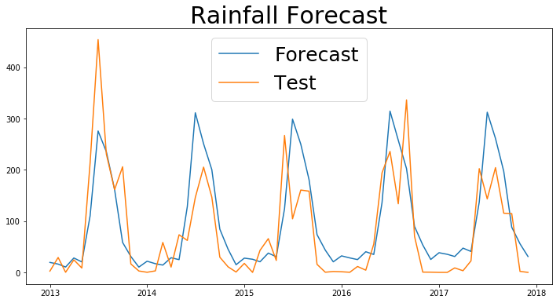

```python
SARIMAX_model(trains4,tests4,orders4,sorders4)
```

## Final Forecast using the Grid Searched Parameters

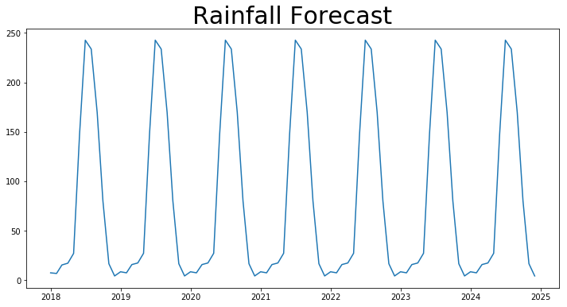

```python
model_gs=SARIMAX(Tdf['Rainfall'],order=(1,0,1),seasonal_order=(0,1,1,12),enforce_stationarity=False,enforce_invertibility=False)
fitted_gs=model_gs.fit(disp=False)
forecasts_gs=fitted_gs.forecast(84)
plt.figure(figsize=(12, 6))
plt.title('Rainfall Forecast', fontsize=30)
plt.plot((forecasts_gs), label='Forecast')
plt.show()
```

### In this model we have less variation but high bias.

```python
forecasts_gs.apply(replacer).resample('Y').sum()
```

```
2018-12-31    949.434286
2019-12-31    950.413238
2020-12-31    950.415506
2021-12-31    950.415511
2022-12-31    950.415511
2023-12-31    950.415511
2024-12-31    950.415511
Freq: A-DEC, dtype: float64
```

## Final Forecast using the AC and PAC Parameters

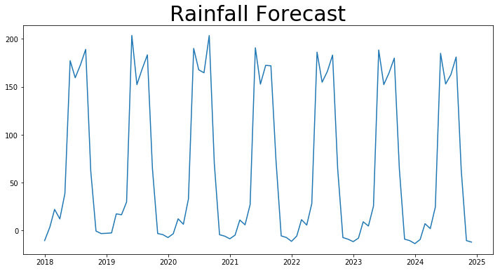

```python
model_b=SARIMAX(Tdf['Rainfall'],order=(3,1,0),seasonal_order=(3,1,0,12),enforce_stationarity=False,enforce_invertibility=False)
fitted_b=model_b.fit(disp=False)
forecasts_b=fitted_b.forecast(84)
plt.figure(figsize=(12, 6))
plt.title('Rainfall Forecast', fontsize=30)
plt.plot((forecasts_b), label='Forecast')
plt.show()
```

### This model we have a good mix of variance and bias. Although we do have some negative values. Now we will have to remove negative values as we cant have rain in real life that is negative.

```python
Final_Annual_Forecast=forecasts_b.apply(replacer).resample('Y').sum()
```

```python
Final_Annual_Forecast
```

```
2018-12-31    822.107824
2019-12-31    836.487393
2020-12-31    829.595251
2021-12-31    788.778427
2022-12-31    783.579273
2023-12-31    775.610772
2024-12-31    770.503103
Freq: A-DEC, dtype: float64
```

```python
forecasts_b.apply(replacer)
```

```
2018-01-01      0.000000
2018-02-01      0.000000
2018-03-01     22.152465
2018-04-01      0.000000
2018-05-01     38.684420
2018-06-01    177.337244
2018-07-01    159.555075
2018-08-01    173.009589
2018-09-01    189.154673
2018-10-01     62.214357
2018-11-01      0.000000
2018-12-01      0.000000
2019-01-01      0.000000
2019-02-01      0.000000
2019-03-01     17.471570
2019-04-01     16.563595
2019-05-01     29.871538
2019-06-01    203.684503
2019-07-01    152.336447
2019-08-01    168.604736
2019-09-01    183.387282
2019-10-01     64.567721
2019-11-01      0.000000
2019-12-01      0.000000
2020-01-01      0.000000
2020-02-01      0.000000
2020-03-01      0.000000
2020-04-01      0.000000
2020-05-01     33.077579
2020-06-01    190.138252
                 ...
2022-07-01    154.884968
2022-08-01    166.072417
2022-09-01    183.193585
2022-10-01     64.905922
2022-11-01      0.000000
2022-12-01      0.000000
2023-01-01      0.000000
2023-02-01      0.000000
2023-03-01      0.000000
2023-04-01      0.000000
2023-05-01     25.528266
2023-06-01    188.503106
2023-07-01    152.372531
2023-08-01    164.594021
2023-09-01    179.995645
2023-10-01     64.617202
2023-11-01      0.000000
2023-12-01      0.000000
2024-01-01      0.000000
2024-02-01      0.000000
2024-03-01      0.000000
2024-04-01      0.000000
2024-05-01     24.655073
2024-06-01    185.014455
2024-07-01    152.983841
2024-08-01    162.794914
2024-09-01    181.139967
2024-10-01     63.914852
2024-11-01      0.000000
2024-12-01      0.000000
Freq: MS, Length: 84, dtype: float64
```

**Next we shall try a completely different method which is a relatively new method for forecasting time series data.**

## Fuzzy Time Series

**How does it work?:**

Our model takes numerical values converts them into multiple categorical variables and interprets the future categorical variables which it then converts back to numerical values.

### The Fuzzy time series uses multiple parameters to try and forecast future values.

#### Variations of the input parameters are below.

**Partitioner**= Grid.GridPartitioner,CMeans.CMeansPartitioner,FCM.FCMPartitioner,Entropy.EntropyPartitioner

**Method**= HighOrderFTS,WeightedHighOrderFTS,ProbabilisticWeightedFTS,chen.ConventionalFTS

**npart**= 10,20,30,40,50,100,200,300,400,500

**Order**= 1,2,3,4,5,6,7,8,9,10,11,12

**Batch_size**= 10,20,30,40,50,60,70,80,90,100

**Window_length**= 50,100,150,200,250,300,350,400,450,500

- The two most important parameters for any model are "npart" and "order". They are the most significant as they tend to predicted scores drastically.
- "Partitioner" and "method" are important as well but they more or less converge to similar results.
- "batch_size" and "window_length" dont have all that too much of an impact on the predictive capability of our model.

```python
FTS_train=np.array(Tdf['Rainfall'].iloc[:-60])
FTS_test=np.array(Tdf['Rainfall'].iloc[-60:])
```

```
3656.9761924969644 60.472937687009754 38.94607413853351
```

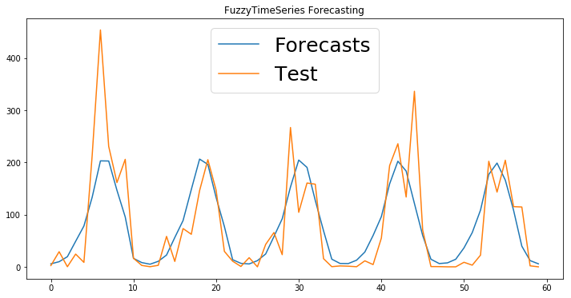

```python
model1 = TimeVariant.Retrainer(
            partitioner_method=Grid.GridPartitioner,
            partitioner_params={'npart':10},
            fts_method=ProbabilisticWeightedFTS,
            fts_params={},
            order=5,
            batch_size=10,
            window_length=200)
model1.fit(FTS_train)
forecasts1=model1.predict(data=FTS_train,steps_ahead=60)
# forecasts1=np.array(forecasts1[:60])
fig=plt.figure(figsize=(12,6))
plt.plot(forecasts1,label='Forecasts')
plt.plot(FTS_test,label='Test')
plt.title('FuzzyTimeSeries Forecasting')
plt.legend(fontsize=25)
print(mean_squared_error(forecasts1,FTS_test),np.sqrt(mean_squared_error(forecasts1,FTS_test)),mean_absolute_error(forecasts1,FTS_test))
```

```python
forecasts1=pd.Series(forecasts1,test.index).apply(replacer)
```

```python
forecasts1.resample('Y').sum()
```

```
Date
2013-12-31    943.706704
2014-12-31    928.222157
2015-12-31    919.162653
2016-12-31    910.747781
2017-12-31    900.428569
Freq: A-DEC, dtype: float64
```

### Final forecast using Fuzzy Time Series.

```python
final_train=np.array(Tdf['Rainfall'])
```

```python
final_model = TimeVariant.Retrainer(
            partitioner_method=Grid.GridPartitioner,
            partitioner_params={'npart':10},
            fts_method=ProbabilisticWeightedFTS,
            fts_params={},
            order=5,
            batch_size=10,
            window_length=200)
final_model.fit(final_train)
final_forecast=final_model.predict(data=final_train,steps_ahead=84)
# forecasts1=np.array(forecasts1[:60])
# fig=plt.figure(figsize=(12,6))
# plt.plot(forecasts1,label='Forecasts')
# plt.plot(FTS_test,label='Test')
# plt.title('FuzzyTimeSeries Forecasting')
# plt.legend(fontsize=25)
# print(mean_squared_error(forecasts1,FTS_test),np.sqrt(mean_squared_error(forecasts1,FTS_test)),mean_absolute_error(forecasts1,FTS_test))
```

```python
final_index=pd.date_range('2018-01-01','2024-12-31',freq='M')
```

```python
final_forecast_replaced=pd.Series(final_forecast,index=final_index).apply(FTS_replacer)
```

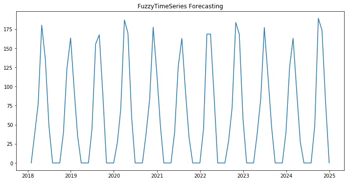

```python
fig=plt.figure(figsize=(12,6))
plt.plot(final_forecast_replaced)
plt.title('FuzzyTimeSeries Forecasting')
plt.show()
```

### This is the final forecast using the Fuzzy Time Series for the years 2018-2024.

### We have introduced some bias in the model so as to conform to the actual results of 2018.

```python
final_forecast_replaced.resample('Y').sum()
```

```
2018-12-31    804.922712
2019-12-31    587.653454
2020-12-31    928.877071
2021-12-31    503.177753
2022-12-31    981.514482
2023-12-31    500.311797
2024-12-31    902.587255
Freq: A-DEC, dtype: float64
```

```python
final_forecast_replaced
```

```
2018-01-31      0.000000
2018-02-28     36.362267
2018-03-31     77.137432
2018-04-30    180.272200
2018-05-31    135.277722
2018-06-30     48.990387
2018-07-31      0.000000
2018-08-31      0.000000
2018-09-30      0.000000
2018-10-31     39.419480
2018-11-30    124.015473
2018-12-31    163.447751
2019-01-31     94.225393
2019-02-28     35.805695
2019-03-31      0.000000
2019-04-30      0.000000
2019-05-31      0.000000
2019-06-30     44.496378
2019-07-31    155.569255
2019-08-31    167.579892
2019-09-30     89.976841
2019-10-31      0.000000
2019-11-30      0.000000
2019-12-31      0.000000
2020-01-31     26.508968
2020-02-29     70.334023
2020-03-31    186.998744
2020-04-30    169.794979
2020-05-31     60.439003
2020-06-30      0.000000
                 ...
2022-07-31      0.000000
2022-08-31     28.305652
2022-09-30     72.098705
2022-10-31    183.808196
2022-11-30    168.455725
2022-12-31     58.374413
2023-01-31      0.000000
2023-02-28      0.000000
2023-03-31      0.000000
2023-04-30     37.397286
2023-05-31     84.409591
2023-06-30    177.156904
2023-07-31    113.717690
2023-08-31     47.063419
2023-09-30      0.000000
2023-10-31      0.000000
2023-11-30      0.000000
2023-12-31     40.566908
2024-01-31    126.182897
2024-02-29    163.082010
2024-03-31     93.025331
2024-04-30     27.465188
2024-05-31      0.000000
2024-06-30      0.000000
2024-07-31      0.000000
2024-08-31     49.546598
2024-09-30    189.252384
2024-10-31    173.568069
2024-11-30     80.464779
2024-12-31      0.000000
Freq: M, Length: 84, dtype: float64
```